# STAT 331 Portfolio

## Program Efficiency

**PE-1: I can write concise code which does not repeat itself.**

- using a single function call with multiple inputs (rather than multiple function calls)

```r
# Lab 5 Part 1
crime_scene_report |>
  mutate(date = ymd(date)) |>
  filter(date == mdy("January 15, 2018"),
         type == "murder",
         city == "SQL City") |>
  select(description)
```

- using `across()`

```r
# Lab 7 Question 1
fish_missing <- fish |>
  summarize(
    obs_missing = sum(if_any(where(~ any(is.na(.x))), is.na)),
    across(
      .cols = where(~ any(is.na(.x))),
      .fns = ~ sum(is.na(.x)),
      .names = "n_missing_{.col}"
    )
  )

fish_missing
```

- using functions from the `map()` family

```r
# Lab 10 Question 1
results <- map_int(.x = 1:10000,
                   .f = ~ randomBabies(4)
                  )
```

**PE-2: I can write functions to reduce repetition in my code.**

- Example 1: Function that operates on vectors

```r
# Challenge 7 Question 2
replace_unlikely <- function(vec, min_val, max_val) {
  if (!is.numeric(min_val)) {
    stop()
  }
  if (!is.numeric(max_val)) {
    stop()
  }
  vec[vec < min_val | vec > max_val] <- NA
  vec
}
```

- Example 2: Function that operates on data frames

```r
# Lab 8 Question 2
pivot_table <- function(data, row_var, col_var) {
  data |>
    count({{ row_var }},
          {{ col_var }}) |>
    pivot_wider(
      names_from  = {{ col_var }},
      values_from = n,
      values_fill = 0
    ) |>
    janitor::adorn_totals("both")
}
```

- Example 3: Function that operates on vectors *or* data frames

```r
# Lab 10 Question 1
rescale_01 <- function(vec){
  if(!is.numeric(vec)) {
    stop()
  }
  if(length(vec) <= 1){
    stop()
  }

  rng <- range(vec, na.rm = TRUE)
  width <- diff(rng)

  (vec - rng[1]) / width
}

rescale_column <- function(df, cols) {
    df |>
      mutate(across(.cols = {{ cols }},
                    .fns = ~ rescale_01(.x)))
}
```

**PE-3:I can use iteration to reduce repetition in my code.**

- using `across()`

```r
# Lab 8 Question 1 (Modified to use named arguments for across)
rescale_01 <- function(vec){
  if(!is.numeric(vec)) {
    stop()
  }
  if(length(vec) <= 1){
    stop()
  }

  rng <- range(vec, na.rm = TRUE)
  width <- diff(rng)

  (vec - rng[1]) / width
}

rescale_column <- function(df, cols) {
    df |>
      mutate(across(.cols = {{ cols }},
                    .fns = ~ rescale_01(.x)))
}
```

- using a `map()` function with **one** input (e.g., `map()`, `map_chr()`, `map_dbl()`, etc.)

```r
# Lab 9 Question 2
map_chr(surveys, typeof) |>
  enframe(name = "Variable", value = "Data Type") |>
  kable()
```

- using a `map()` function with **one** input

```r
# Lab 9 Question 4
evals_new <- map_if(evals, is.character, as.factor) |>
  bind_cols()
```

**PE-4: I can use modern tools when carrying out my analysis.**

- I can use functions which are not superseded or deprecated

```r
# Lab 5 Part 3 (Uses join_by)
get_fit_now_member |>
  left_join(get_fit_now_check_in, by = join_by(id == membership_id)) |>
  mutate(check_in_date = ymd(check_in_date)) |>
  filter(month(check_in_date) == 1,
         day(check_in_date) == 9,
         membership_status == "gold",
         str_detect(id, pattern = "48Z")) |>
  left_join(person, by = join_by(person_id == id)) |>
  left_join(drivers_license, by = join_by(license_id == id)) |>
  filter(str_detect(plate_number, pattern = "H42W")) |>
  left_join(interview, by = "person_id") |>
  select(transcript)
```

- I can connect a data wrangling pipeline into a `ggplot()`

```r
# Modified Lab 4 Question 7 to use named arguments
ca_childcare |>
  rename(
      Infant = mc_infant,
      Toddler = mc_toddler,
      Preschool = mc_preschool
  ) |>
  pivot_longer(cols = c(Infant, Toddler, Preschool),
               names_to = "age_group",
               values_to = "median_price"
               ) |>
  mutate(
    region = fct_reorder2(region, study_year, median_price),
    age_group = fct_relevel(age_group, "Infant", "Toddler", "Preschool")
  ) |>
  ggplot(mapping = aes(x = study_year, y = median_price, color = region)) +
    geom_point() +
    scale_x_continuous(breaks = seq(2008, 2018, 2)) +
    scale_y_continuous(breaks = seq(0, 500, 100),
                       limits = c(100, 500)) + #https://ggplot2.tidyverse.org/reference/scale_continuous.html
    facet_wrap(~ age_group) +
    geom_smooth(method = "loess") +
    theme_bw() +
    labs(title = "Weekly Median Price for Center-Based Childcare ($)",
         x = "Study Year",
         y = NULL,
         color = "California Region")
```

## Data Simulation & Statisical Models

**DSSM-1: I can simulate data from a *variety* of probability models.**

- Example 1

```r
# Lab 10 Question 4
# define slope and intercept parameters
intercept = 2
slope = 1

# generate x vector
x = runif(n = 100, min = 0, max = 1)

# generate noise `ep` vector
ep = rnorm(n = 100, mean = 0, sd = 1)

# generate outcome from population model
y = intercept + x*slope + ep


# create an "observed data" dataframe with only the x and y vectors
obs_data <- data.frame(x, y)
obs_data
```

- Example 2

```r
# Lab 10 Question 8
mycifun <- function(beta0, beta1, n) {
  x  <- runif(n, min = 0, max = 1)
  ep <- rnorm(n, mean = 0, sd = 1)
  y  <- beta0 + beta1 * x + ep
  obs_data <- data.frame(x, y)

  model <- lm(y ~ x, data = obs_data)

  model_tidy <- tidy(model, conf.int = TRUE)

  model_tidy |>
    mutate(cover = ifelse(term == "x" &
                            beta1 >= conf.low &
                            beta1 <= conf.high, 1, 0)) |>
    filter(term == "x") |>
    select(
      slope_hat = estimate,
      ci_low = conf.low,
      ci_high = conf.high,
      cover
    )
}
```

**DSSM-2: I can conduct common statistical analyses in R.**

- Example 1

```r
# Lab 2 Question 17
species_mod <- aov(weight ~ species, data = surveys)
summary(species_mod)
```

- Example 2

```r
# Lab 4 Question 9
reg_mod1 <- lm(mc_infant ~ mhi_2018, data = ca_childcare)
summary(reg_mod1)
```

- Example 3

```r
# Lab 1 Question 9
t.test(len ~ supp, data = ToothGrowth)
```

## Revising My Thinking

Throughout the course, I spent a lot of time looking back on code I got feedback for. The nature of the feedback varies, from peer feedback to professor feedback, but there was usually something to change, whether small or big. While I just kept the small changes in the back of my mine, I usually went and resubmitted any larger changes. Oftentimes, the feedback helped me consider different approaches to my work, and made my work cleaner or more understandable. For instance, I received a lot of feedback about making my labels and titles more descriptive, which I keep in mine for future assignments. For the code examples in the portfolio, this was also valuable as I once again went back and searched for what code chunks were the best examples for each of the learning targets. It allowed me to really think about what a code chunk is doing, and again if there are any other better ways to do something. I also received a lot of good feedback when I submitted this portfolio for the midterm. I made sure to address every single comment made of my midterm portfolio submission, and this once again reinforced syntactical and logical ideas specific to R.

## Extending My Thinking

Throughout the course, I found a common theme to be that much of the course content is repeated. For instance, we learned how to build plots first, but then continued using them when we learned dplyr pipelines. We simply expanded the use cases for them, to build more descriptive or meaningful plots. I feel like this is a core theme in this course and many courses; continuing to revise past content through the application of such content later in the course is critical to expanding one’s thinking, and helped me in this course. For the portfolio, as mentioned before, actually thinking about relevant examples for each chunk was a great experience. Additionally, actually modifying my code chunks for targets I didn’t have an example for made me think about different approaches to the same problem, and were sometimes cleaner than what I had originally done. This is a core part of expanding my thinking, as it made me consider different approaches before I even started problems.

## Peer Support & Collaboration

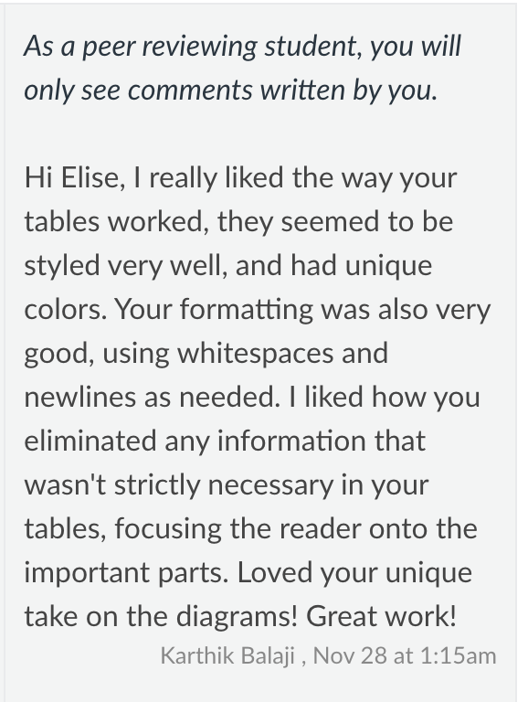

The main thing that helped me grow as a collaborator was taking other people’s inputs and suggestions in a meaningful way. By fully listening to what other people are saying and implementing this, oftentimes I would do it in a different way than I originally intended. This was cool to see as it showed me how other people think, and expanded my brain a little bit to think about different solutions to a problem. Even if they didn’t get it right, we could work through the correct solution afterwords. As the talker, I was able to test my ideas fully as well, and work through the same process but on the other side; it was cool to see some of my thoughts fully validated.